# Rice price project — data sanity checks

## 3.2 Tax basis, stitching, consistency

```r
cmp <- inner_join(m |> filter(x1_src == "crop_year_file") |> select(date, x1), r1 |> select(date, x1_release), by = "date")
add("X1 tax basis", "PASS", "File headers state 円／玄米60㎏税込 (tax-inclusive): the spec's divide-by-1.05/1.08 applies")
add("X1 file vs monthly-release agreement", ifelse(all(cmp$x1 == cmp$x1_release), "PASS", "FLAG"),
    sprintf("%d overlapping months, max |diff| = %g", nrow(cmp), max(abs(cmp$x1 - cmp$x1_release))))
```

- **Tax:** every file header says *円／玄米60㎏税込*, so the spec’s divide-by-1.05/1.08 applies. Caveat: MAFF’s figures are based on contract prices including tax. The 2014 rate change lands at the September 2014 crop switch, which is mixed in with a −9% supply-driven fall, so it can’t be checked from the data.
- **Two sources agree:** the crop-year files and the separate monthly releases give identical values for all 37 overlapping months (max difference 0).
- **No overlap to stitch:** each calendar month belongs to exactly one crop year (Sep–Aug), so the “current crop” rule is automatic. The real issue is the next point.

## 3.3 X1 is close to a step function

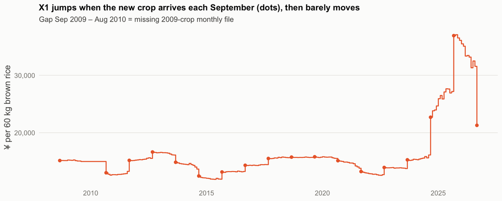

```r
x1d <- m |> filter(date >= as.Date("2010-09-01")) |> mutate(dl = dlog(x1), sep = format(date, "%m") == "09")
share_sep <- with(x1d, sum(abs(dl[sep]), na.rm = TRUE) / sum(abs(dl), na.rm = TRUE))
ggplot(m |> filter(!is.na(x1)), aes(date, x1)) +
  geom_step(colour = pal["orange"], linewidth = 0.6) +
  geom_point(data = ~ filter(.x, format(date, "%m") == "09"), colour = pal["orange"], size = 1.5) +
  scale_y_continuous(labels = scales::comma) +
  labs(x = NULL, y = "¥ per 60 kg brown rice", title = "X1 jumps when the new crop arrives each September (dots), then barely moves",
       subtitle = "Gap Sep 2009 – Aug 2010 = missing 2009-crop monthly file")
```

```r
add("X1 within-year variation", "FLAG",
    sprintf("%.0f%% of total |Δlog X1| since Sep 2010 happens in September; Δlog X1 is a once-a-year spike series", 100 * share_sep))
```

**59% of all absolute monthly change in X1 since 2010 happens in September**, when the new crop’s prices replace the old crop’s. September is 1 month in 12. Within a crop year X1 drifts slowly: 76% of months move by less than 1%. For modelling:

- Δlog X1 is mostly zeros with one spike per year. It will show a spike at lag 12 in its own ACF, and it makes CCFs and Granger tests depend heavily on about 15 September values.
- Retail prices adjust more smoothly. Expect the “wholesale leads retail by 1–3 months” story to show up mainly as **September spikes in X1 followed by retail moves in Oct–Dec**.

## 3.4 New-crop volume (thin-month check)

```r
vol <- r1 |> filter(format(date, "%m") %in% c("09", "10")) |> transmute(Month = format(date, "%Y-%m"), `Crop year` = as.character(crop_year),
                                                                          `Price (¥/60kg)` = x1_release, `Volume (t)` = volume_t)
kable(vol, format.args = list(big.mark = ","))
```

| Month | Crop year | Price (¥/60kg) | Volume (t) |
| --- | --- | --- | --- |
| 2022-09 | 2022 | 13,961 | 150,628 |
| 2022-10 | 2022 | 13,898 | 191,774 |
| 2023-09 | 2023 | 15,291 | 128,979 |
| 2023-10 | 2023 | 15,181 | 171,630 |
| 2024-09 | 2024 | 22,700 | 252,373 |
| 2024-10 | 2024 | 23,820 | 274,490 |
| 2025-09 | 2025 | 36,895 | 160,287 |
| 2025-10 | 2025 | 37,058 | 336,796 |
| 2026-09 | 2026 | 21,293 | 53,814 |

```r
sep26 <- r1 |> filter(date == as.Date("2026-09-01"))
x1_drop <- 100 * (m$x1[m$date == as.Date("2026-09-01")] / m$x1[m$date == as.Date("2026-08-01")] - 1)  # % change, not log
add("Latest X1 month (Sep 2026)", "FLAG",
    sprintf("New 2026 crop opens at ¥%s (%.1f%% vs Aug) on only %s t, about a third of earlier Septembers: preliminary and thin",
            format(sep26$x1_release, big.mark = ","), x1_drop, format(sep26$volume_t, big.mark = ",")))
```

Volumes are published only in the monthly releases (from the 2022 crop). **September 2026, the latest month, prices the new crop at ¥21,293, down 32.5% from August, on 53,814 t.** That’s about a third of earlier Septembers. It’s a 速報 (preliminary) value from a thin month, and it will be revised. It’s also the single most informative data point for the client’s question, so treat it carefully: flag it, and check the forecast’s sensitivity to it.

# 4. X2 — BOJ import price index (yen basis)

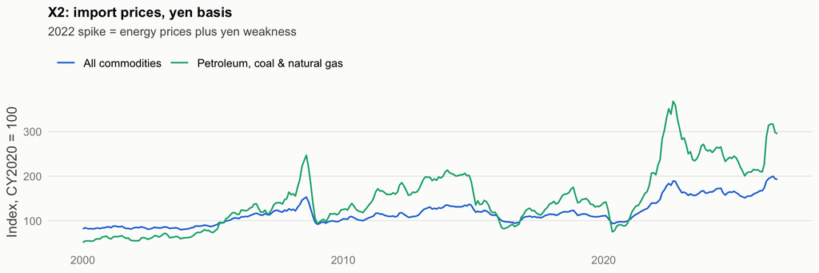

```r
z <- m |> filter(!is.na(x2_all_2015base)) |> mutate(ratio = x2_all / x2_all_2015base)
ggplot(m |> filter(!is.na(x2_all)) |> select(date, `All commodities` = x2_all, `Petroleum, coal & natural gas` = x2_energy) |>
         pivot_longer(-date), aes(date, value, colour = name)) +
  geom_line(linewidth = 0.6) + scale_colour_manual(values = unname(pal[c("blue", "aqua")])) +
  labs(x = NULL, y = "Index, CY2020 = 100", title = "X2: import prices, yen basis",
       subtitle = "2022 spike = energy prices plus yen weakness")
```

```r
add("X2 coverage & rebasing", ifelse(sd(z$ratio) < 0.01, "PASS", "FLAG"),
    sprintf("Jan 2000–%s, no gaps; ratio of 2020-base to 2015-base series is %.3f ± %.4f, so the history is cleanly linked",
            format(max(m$date[!is.na(m$x2_all)]), "%b %Y"), mean(z$ratio), sd(z$ratio)))
```

The BOJ’s 2020-base series (`PRCG20_2600000000`) is linked back to 1960. Where it overlaps the old 2015-base series, the ratio is 1.18 ± 0.0035, so there are no rebasing jumps. The units are yen basis, not contract currency (series code `…26…`). The energy subgroup (`PRCG20_2600520001`) is also kept as an alternative X2.

# 5. X3 — Niigata August temperature anomaly

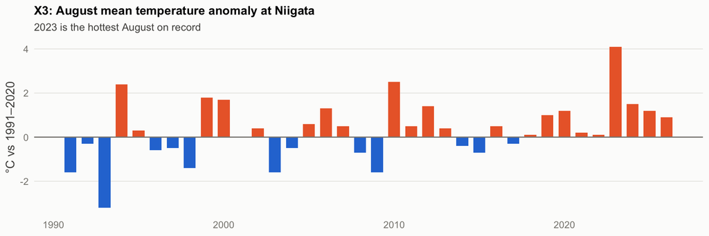

```r
x3w <- x3y |> filter(year >= 1991)
rank23 <- rank(-x3y$aug_temp)[x3y$year == 2023]
ggplot(x3w, aes(year, aug_anom)) +
  geom_col(fill = ifelse(x3w$aug_anom >= 0, pal["orange"], pal["blue"]), width = 0.7) +
  geom_hline(yintercept = 0, colour = muted) +
  labs(x = NULL, y = "°C vs 1991–2020", title = "X3: August mean temperature anomaly at Niigata",
       subtitle = "2023 is the hottest August on record")
```

```r
flags <- x3y |> filter(year >= 1991, aug_flag != "")
add("X3 plausibility", "PASS",
    sprintf("Aug 2023 = %.1f °C (rank %d of %d years since 1881). Our 1991–2020 normal %.2f vs JMA's %.1f (diff %.2f); anomalies now use JMA's. No quality flags on August values since 1991",
            x3y$aug_temp[x3y$year == 2023], rank23, sum(!is.na(x3y$aug_temp)), x3y$our_normal[1], x3y$jma_normal[1],
            x3y$our_normal[1] - x3y$jma_normal[1]))
```

# 5b. X3b — Niigata Jun–Aug precipitation

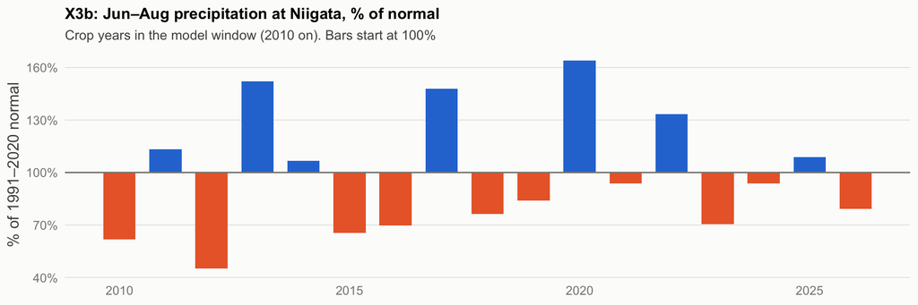

```r
pb <- read.csv("data/interim/x3b_niigata_jja_precip.csv")
pbw <- pb |> filter(year >= 2010)
both <- inner_join(pb, x3y, by = "year") |> filter(year >= 2010)
r_tp <- cor(both$jja_pct, both$aug_anom)
ggplot(pbw, aes(year, jja_pct - 100)) +
  geom_col(fill = ifelse(pbw$jja_pct >= 100, pal["blue"], pal["orange"]), width = 0.7) +
  geom_hline(yintercept = 0, colour = muted) +
  scale_y_continuous(labels = function(v) paste0(v + 100, "%")) +
  labs(x = NULL, y = "% of 1991–2020 normal", title = "X3b: Jun–Aug precipitation at Niigata, % of normal",
       subtitle = "Crop years in the model window (2010 on). Bars start at 100%")
```

```r
dry <- pbw |> arrange(jja_pct) |> head(3); wet <- pbw |> arrange(desc(jja_pct)) |> head(3)
add("X3b precipitation", "PASS",
    sprintf("%d complete summers 1991–2026, no quality flags. JJA normal: ours %.1f mm vs JMA %.1f mm. Correlation with the Aug temperature anomaly since 2010: %.2f",
            nrow(pb), pb$jja_normal_own[1], pb$jja_normal_jma[1], r_tp))
```

- All 36 summers since 1991 are complete, with no JMA quality markers. Our 1991–2020 Jun–Aug mean (506.7 mm) matches JMA’s official normal (506.8 mm), and the % of normal uses JMA’s.
- Driest summers in the window: 2012 (45%), 2010 (62%), 2015 (65%). Wettest: 2020 (164%), 2013 (152%), 2017 (148%).
- **2023 was 70% of normal for the season, but August 2023 alone had just 2.0 mm of rain** (normal 163.4 mm), during the hottest August on record. A wet June (182.5 mm, 151% of normal) and a slightly dry July (172.5 mm, 78%) hide that in the three-month total. Keep this in mind if precipitation looks weak in the VAR: an August-only measure would capture the 2023 drought more sharply.
- Correlation with the temperature anomaly across the 17 crop years since 2010 is **-0.31**: hot summers tend to be dry, but not enough to cause collinearity problems. Like X3, X3b has one value per crop year, so it’s an exogenous step regressor with 17 distinct values in the window (crop years 2010–2026).

# 6. X4 — JNTO visitor arrivals

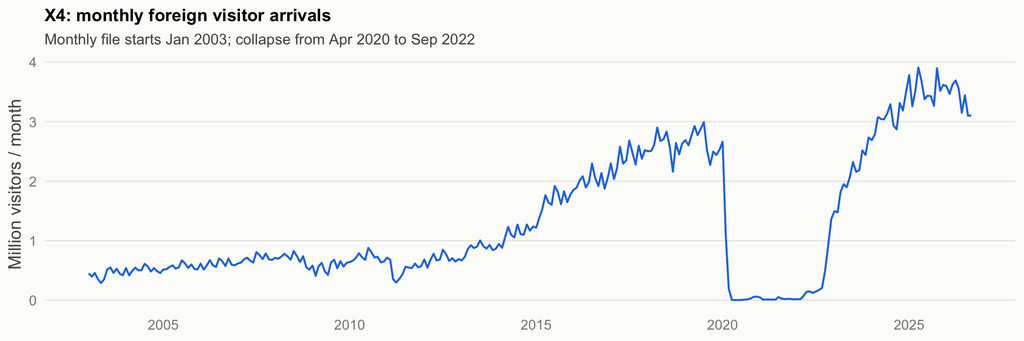

```r
ggplot(m |> filter(!is.na(x4)), aes(date, x4 / 1e6)) + geom_line(colour = pal["blue"], linewidth = 0.6) +
  labs(x = NULL, y = "Million visitors / month", title = "X4: monthly foreign visitor arrivals",
       subtitle = "Monthly file starts Jan 2003; collapse from Apr 2020 to Sep 2022")
```

```r
add("X4 coverage", "FLAG", "Monthly data from Jan 2003 (not 2000). Covers the X1 window fully. Near-zero 2020–22. Recent months are JNTO estimates (推計値) and get revised")
```

The monthly JNTO file starts in **2003**, not 2000. That doesn’t matter, because the window starts in 2010 anyway. The 2020–22 collapse is there as expected. The latest months are JNTO estimates (推計値) and will be revised.

# 7. Cross-series checks (EDA preview)

## 7.1 Do retail and wholesale move together?

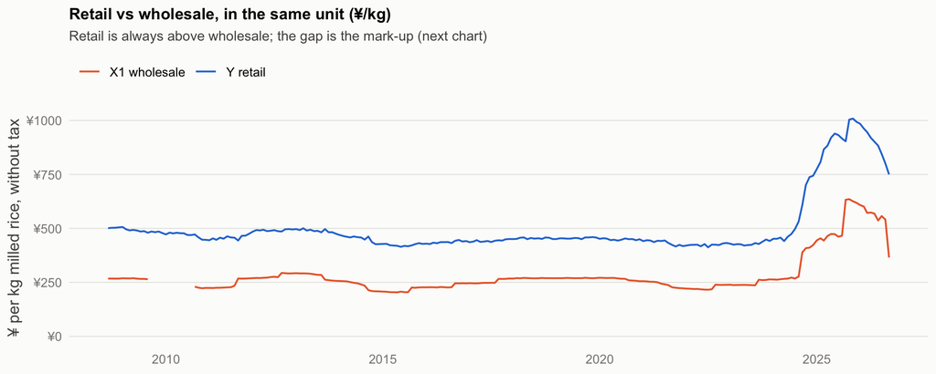

```r
ov <- m |> filter(date >= as.Date("2008-09-01")) |>
  mutate(y_ex = y / ifelse(date < as.Date("2014-04-01"), 1.05, 1.08),
         x1_ex = x1 / ifelse(date < as.Date("2014-04-01"), 1.05, 1.08))
# same unit for both: ¥ per kg of milled rice (wholesale: 60 kg brown rice -> 54 kg milled at a 0.9 yield)
ovl <- ov |> transmute(date, `Y retail` = y_ex / 5, `X1 wholesale` = x1_ex / 54) |> pivot_longer(-date)
p <- ggplot(ovl, aes(date, value, colour = name)) + geom_line(linewidth = 0.6, na.rm = TRUE) +
  scale_colour_manual(values = c(`Y retail` = unname(pal["blue"]), `X1 wholesale` = unname(pal["orange"]))) +
  scale_y_continuous(labels = function(v) paste0("¥", v), limits = c(0, NA)) +
  labs(x = NULL, y = "¥ per kg milled rice, without tax")
p + labs(title = "Retail vs wholesale, in the same unit (¥/kg)",
         subtitle = "Retail is always above wholesale; the gap is the mark-up (next chart)")
```

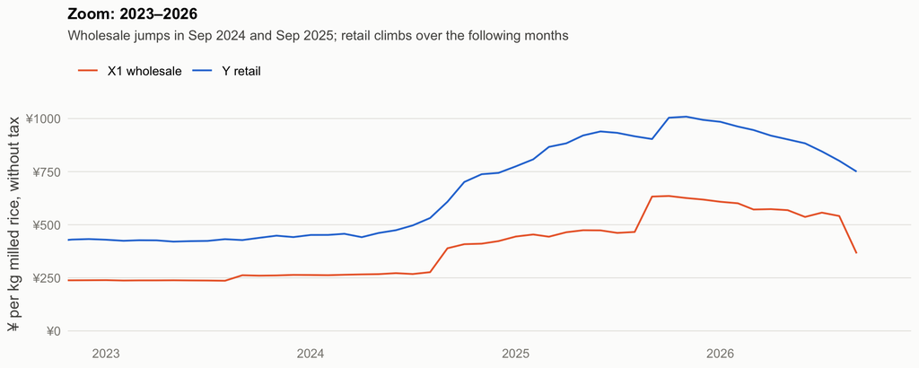

```r
p + coord_cartesian(xlim = as.Date(c("2023-01-01", "2026-09-30"))) +
  labs(title = "Zoom: 2023–2026", subtitle = "Wholesale jumps in Sep 2024 and Sep 2025; retail climbs over the following months")
```

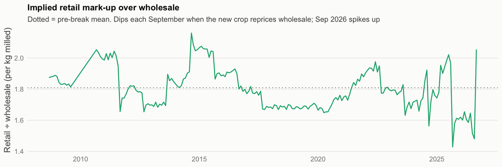

```r
# 60 kg brown rice -> ~54 kg milled at a 0.9 milling yield; compare per kg
mg <- ov |> mutate(retail_per_kg = y_ex / 5, wholesale_per_kg = x1_ex / (60 * 0.9), ratio = retail_per_kg / wholesale_per_kg)
pre_ratio <- mg |> filter(date >= as.Date("2010-09-01"), date < as.Date("2024-08-01")) |> pull(ratio)
ggplot(mg |> filter(!is.na(ratio)), aes(date, ratio)) + geom_line(colour = pal["aqua"], linewidth = 0.6) +
  geom_hline(yintercept = mean(pre_ratio), colour = muted, linetype = 3) +
  labs(x = NULL, y = "Retail ÷ wholesale (per kg milled)", title = "Implied retail mark-up over wholesale",
       subtitle = "Dotted = pre-break mean. Dips each September when the new crop reprices wholesale; Sep 2026 spikes up")
```

- Before the break the mark-up ratio averaged **1.81** (sd 0.12). Retail and wholesale share a long-run level, which hints at cointegration. That’s the spec’s VECM caveat, and it now looks more relevant than a footnote.
- Each September’s wholesale jump **squeezes the mark-up** (Sep 2024: 1.56; Sep 2025: 1.43). Retail then catches up over the following months, which is the lead/lag pattern a VAR or VECM should pick up. Through the 2025 crop year the mark-up stayed below its pre-break mean, at about 1.6.
- **September 2026 flips this.** Wholesale falls 32.5%, and the mark-up jumps to **2.05**, above the pre-break mean and near the top of its pre-break range (1.63–2.16). If the old relationship holds, **retail has room to keep falling**. That’s the key fact for the client, though it rests on one thin preliminary month (section 3.4).

## 7.2 Lead/lag: cross-correlations

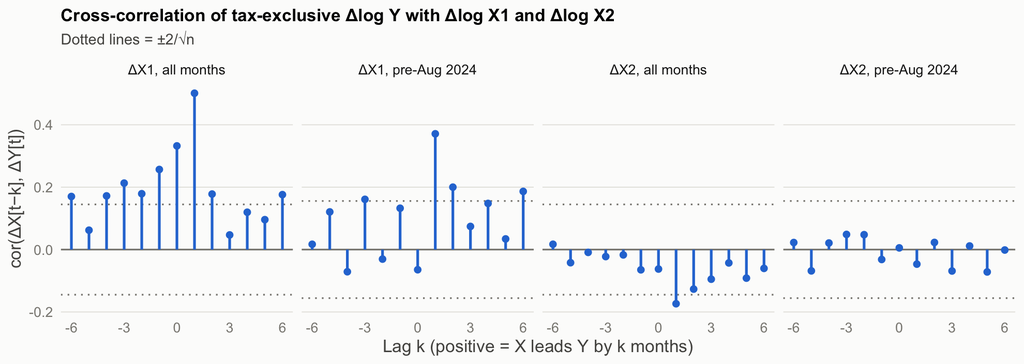

```r
cc <- m |> filter(date >= as.Date("2010-10-01")) |>
  mutate(dy = dlog(y / ifelse(date < as.Date("2014-04-01"), 1.05, 1.08)),
         dx1 = dlog(x1 / ifelse(date < as.Date("2014-04-01"), 1.05, 1.08)), dx2 = dlog(x2_all)) |> filter(!is.na(dy))
ccdf <- function(x, lab, d) { k <- ccf(d[[x]], d$dy, lag.max = 6, plot = FALSE, na.action = na.pass)
  data.frame(lag = -k$lag[, 1, 1], r = k$acf[, 1, 1], series = lab, n = sum(complete.cases(d[[x]], d$dy))) }
pre <- cc |> filter(date < as.Date("2024-08-01"))
cdat <- bind_rows(ccdf("dx1", "ΔX1, all months", cc), ccdf("dx1", "ΔX1, pre-Aug 2024", pre),
                  ccdf("dx2", "ΔX2, all months", cc), ccdf("dx2", "ΔX2, pre-Aug 2024", pre))
ci <- 2 / sqrt(nrow(cc)); ci_pre <- 2 / sqrt(nrow(pre))
ggplot(cdat, aes(lag, r)) + geom_hline(yintercept = 0, colour = muted) +
  geom_hline(aes(yintercept = 2 / sqrt(n)), linetype = 3, colour = muted) +
  geom_hline(aes(yintercept = -2 / sqrt(n)), linetype = 3, colour = muted) +
  geom_segment(aes(xend = lag, yend = 0), colour = pal["blue"], linewidth = 0.8) + geom_point(colour = pal["blue"], size = 1.6) +
  facet_wrap(~series, nrow = 1) + scale_x_continuous(breaks = seq(-6, 6, 3)) +
  labs(x = "Lag k (positive = X leads Y by k months)", y = "cor(ΔX[t−k], ΔY[t])",
       title = "Cross-correlation of tax-exclusive Δlog Y with Δlog X1 and Δlog X2",
       subtitle = "Dotted lines = ±2/√n")
```

```r
top <- cdat |> group_by(series) |> slice_max(abs(r), n = 2) |> mutate(r = round(r, 2)) |> select(series, lag, r)
kable(top, caption = "Two largest |r| per panel")
```

Two largest |r| per panel

| series | lag | r |
| --- | --- | --- |
| ΔX1, all months | 1 | 0.50 |
| ΔX1, all months | 0 | 0.33 |
| ΔX1, pre-Aug 2024 | 1 | 0.37 |
| ΔX1, pre-Aug 2024 | 2 | 0.20 |
| ΔX2, all months | 1 | -0.17 |
| ΔX2, all months | 2 | -0.13 |
| ΔX2, pre-Aug 2024 | 5 | -0.07 |
| ΔX2, pre-Aug 2024 | 3 | -0.07 |

```r
x1lead <- cdat |> filter(series == "ΔX1, pre-Aug 2024", lag %in% 1:3) |> arrange(lag)
add("X1 leads Y?", ifelse(any(abs(x1lead$r) > ci_pre), "PASS", "FLAG"),
    sprintf("Pre-break CCF at lags 1–3: %s (±%.2f band). Full-sample CCF is dominated by 2024–25", paste(round(x1lead$r, 2), collapse = ", "), ci_pre))
x2lead <- cdat |> filter(series == "ΔX2, pre-Aug 2024", lag %in% 1:6)
add("X2 leads Y?", ifelse(any(abs(x2lead$r) > ci_pre), "PASS", "FLAG"),
    sprintf("Pre-break max |r| at lags 1–6 = %.2f (±%.2f band)", max(abs(x2lead$r)), ci_pre))
```

## 7.3 Post-break sample and the holdout

```r
post <- m |> filter(date >= as.Date("2024-08-01"))
add("Post-break sample", "FLAG",
    sprintf("%d months since Aug 2024. The 12-month holdout (Oct 2025–Sep 2026) lies wholly inside the shortage regime and includes the start of the decline", nrow(post)))
```

- There are **26 months** of post-break data (Aug 2024 → Sep 2026). A shortage dummy fitted on about 26 months leaves little room for dynamics.
- The 12-month holdout (Oct 2025 – Sep 2026) is **entirely post-break** and includes the turn: retail peaked around ¥5,448 and is now ¥4,051. Holdout ASE will mostly measure who caught the turn, so the spec’s pre/post split of rolling ASE is essential, not optional.

# Summary — go / revise

```r
st <- bind_rows(status)
kable(st, align = "lll")
```

| Check | Result | Detail |
| --- | --- | --- |
| Y coverage | PASS | 321 months, Jan 2000–Sep 2026, no gaps, no ‘-’/‘…’ placeholders |
| Y item continuity | FLAG | Unit was 10 kg before Jan 2002 (fixed and flagged); Nov 2009 wording only; no revisions in 2007/2012/2026 |
| Tax steps in Y | PASS | Apr 2014 Δlog = 0.021 vs 0.028 expected; Oct 2019 shows no step. Tax-exclusive Δlog in Apr 2014 = -0.007 |
| X1 history | FAIL | The 相対取引価格 series starts with the 2006 crop, not 1990. Monthly files exist for the 2008 crop and 2010 on; 2006, 2007 and 2009 crops have annual averages only (not on MAFF’s site or in web archives) |
| X1 tax basis | PASS | File headers state 円／玄米60㎏税込 (tax-inclusive): the spec’s divide-by-1.05/1.08 applies |
| X1 file vs monthly-release agreement | PASS | 37 overlapping months, max \|diff\| = 0 |
| X1 within-year variation | FLAG | 59% of total \|Δlog X1\| since Sep 2010 happens in September; Δlog X1 is a once-a-year spike series |
| Latest X1 month (Sep 2026) | FLAG | New 2026 crop opens at ¥21,293 (-32.5% vs Aug) on only 53,814 t, about a third of earlier Septembers: preliminary and thin |
| X2 coverage & rebasing | PASS | Jan 2000–Sep 2026, no gaps; ratio of 2020-base to 2015-base series is 1.180 ± 0.0035, so the history is cleanly linked |
| X3 plausibility | PASS | Aug 2023 = 30.6 °C (rank 1 of 146 years since 1881). Our 1991–2020 normal 26.61 vs JMA’s 26.5 (diff 0.11); anomalies now use JMA’s. No quality flags on August values since 1991 |
| X3b precipitation | PASS | 36 complete summers 1991–2026, no quality flags. JJA normal: ours 506.7 mm vs JMA 506.8 mm. Correlation with the Aug temperature anomaly since 2010: -0.31 |
| X4 coverage | FLAG | Monthly data from Jan 2003 (not 2000). Covers the X1 window fully. Near-zero 2020–22. Recent months are JNTO estimates (推計値) and get revised |
| X1 leads Y? | PASS | Pre-break CCF at lags 1–3: 0.37, 0.2, 0.07 (±0.16 band). Full-sample CCF is dominated by 2024–25 |
| X2 leads Y? | FLAG | Pre-break max \|r\| at lags 1–6 = 0.07 (±0.16 band) |
| Post-break sample | FLAG | 26 months since Aug 2024. The 12-month holdout (Oct 2025–Sep 2026) lies wholly inside the shortage regime and includes the start of the decline |

## Recommendation: **revise the plan in a few targeted ways, then go**

The data supports the project’s core: a clean Y, a strong wholesale lead indicator, and a visible turning point that matters to the client. Four spec assumptions were wrong or fragile. Each has been resolved as follows:

| # | Issue | Resolution (2026-11-13) | Status |
| --- | --- | --- | --- |
| 1 | Monthly X1 only exists from Sep 2010 | **Sep 2010 → latest for all models** (193 months), applied in `R/20_prepare_model_data.R`. The pre-break sensitivity fit is Sep 2010 – Jul 2024 | Resolved |
| 2 | Jan 2007 / Jan 2012 dummies have no basis for item 1001 | Dropped. Only the shortage dummy (Aug 2024 on) is kept. The Jan 2002 unit change falls outside the window | Resolved |
| 3 | X1 is a crop-year step series | `sep` indicator added to the model data. The VECM is a parallel check to cointegration in the EDA | Carry into EDA |
| 4 | Sep 2026 X1 is thin and preliminary | Flagged (`x1_thin`, `x1_prelim`). The October release wasn’t out on 2026-11-13: re-run `R/02` → `R/10` → `R/20` when it appears | **Open** |

Also added: Niigata Jun–Aug precipitation (X3b, section 5b), and rolling-window evaluation with a 96-month training window alongside the 12-month holdout.

Unchanged: tax-exclusive modelling (the April 2014 step behaves as expected for Y; X1 is tax-inclusive per MAFF), X2 (clean), X3 (clean, exogenous), and X4 (optional; covers the window).